# Homework 4 for Stat 340; Estimation

Karl Rohe

### 1) Planting seeds

Suppose you plant 10,000 seeds and 7,334 germinate. Estimate the probability of seed germination and provide a 95% confidence interval.

```r
library(tidyverse)
library(purrr)
```

```r
n = 10000
phat = 7334 / 10000

phat
```

```
## [1] 0.7334
```

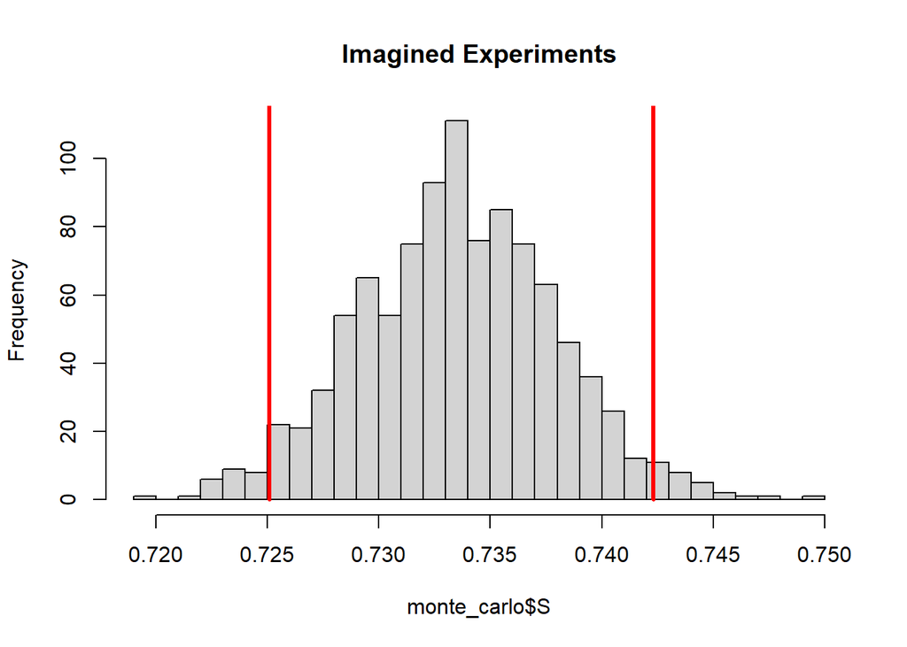

```r
simulate_S = function(){
  X = rbernoulli(n = n, phat)
  S = mean(X)
  return(S)
}

## monte_carlo
r = 1000
monte_carlo = data.frame(replicate = 1:r,
                         S = rep(NA,r))
for(i in 1:r){
  monte_carlo$S[i] = simulate_S()
}

monte_carlo = as_tibble(monte_carlo)

qs = monte_carlo$S %>% quantile(prob =c(.025, .975))

hist(monte_carlo$S, main = "Imagined Experiments", breaks = 30)
lines(qs[1]*c(1,1), c(0,10^9), col = "red", lwd = 3)
lines(qs[2]*c(1,1), c(0,10^9), col = "red", lwd = 3)
```

### 2) Light bulbs

Suppose you install 10 light bulbs. This is how many days it takes them to burn out:

```r
burn_out = c(103,6,517,254,966,381,286,535,239,67)
```

If we model the days to burn out as Geometric(p), then a good estimate for $p$ is…

```r
phat = 1/mean(burn_out)
```

```r
n = length(burn_out)

simulate_S = function(){
  X = rbernoulli(n = n, phat)
  S = mean(X)
  return(S)
}


r = 1000
monte_carlo = data.frame(replicate = 1:r,
                         S = rep(NA,r))
for(i in 1:r){
  monte_carlo$S[i] = simulate_S()
}

monte_carlo = as_tibble(monte_carlo)

qs = monte_carlo$S %>% quantile(prob =c(.025, .975))
qs
```

```
##  2.5% 97.5%
##     0     0
```

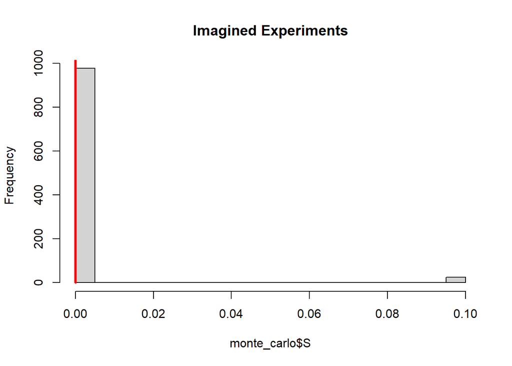

```r
hist(monte_carlo$S, main = "Imagined Experiments", breaks = 30)
lines(qs[1]*c(1,1), c(0,10^9), col = "red", lwd = 3)
lines(qs[2]*c(1,1), c(0,10^9), col = "red", lwd = 3)
```

### 3) Green Bay Packers

The Green Bay Packers won 13 of their 16 regular season games this year (2019). Propose a statistical model with random variables for their wins and loses. We will estimate their win probabilty as $13/16 \approx .81$ Notice that, so far, we have only discussed 95% confidence intervals. What needs to change to make it a 90% interval? Generate a 90% confidence interval for the true probability.

```r
#  X1,…,Xn∈{0,1} where Xi = 1 denotes packers win the game in week i.
n = 16
phat = 13/16

simulate_S = function(){
  X = rbernoulli(n=n,  phat)
  S = mean(X)
  return(S)
}

r = 1000
monte_carlo = data.frame(replicate = 1:r,
                         S = rep(NA,r))
for(i in 1:r){
  monte_carlo$S[i] = simulate_S()
}

monte_carlo = as_tibble(monte_carlo)

qs = monte_carlo$S %>% quantile(prob =c(.050, .950))
qs
```

```
##     5%    95%
## 0.6250 0.9375
```

**4a) Distribution of tags**

What are two or three distributions that we could use for the number of July fish with June tags? There are at least two pretty good answers that we’ve talked about in class. And one “more correct” answer that we haven’t yet talked about.

*We could use a binomial distribution or a normal distribution. We could also possibly do a hypergeom distribution.*

**4b) Do any of these models include N, the total number of pike?**

We want to estimate $N$, the total number of pike in Mendota. Find a distribution for 2a that includes $N$.

*Binomial distribution includes N, as its binom(n,p).*

**4c) Now, think more like your grandparents…**

- Estimate the following probability… Given that you catch a pike in July, what is the probability of it having a June tag? *8(number of fish with june tags caught) / 502 (number of fish caught in july)*
- Suppose you actually knew the total number of pike is $N$. What is the actual probability of catching a pike with a June tag? *it would be: 500 (tagged june fish) / N (number of total fish)*

**4d) Estimate $N$**

Set the two quantities in the second problem above equal to one another and solve for $N$. What is your estimate for $N$, the total number of pike?

*( 8 / 502 ) = (500 / N). N comes out to be 31,375.*

**4e) Make a confidence interval**

Create a 95% confidence interval for your grandparent-estimate from 4d. What assumptions will you need to make to simulate this process? *Assume what N is from 4d*

```r
phat = 8 / 502
n = 31375

simulate_S = function(){
  X = rbernoulli(n=n,  phat)
  S = mean(X)
  return(S)
}

r = 1000
monte_carlo = data.frame(replicate = 1:r,
                         S = rep(NA,r))
for(i in 1:r){
  monte_carlo$S[i] = simulate_S()
}

monte_carlo = as_tibble(monte_carlo)

qs = monte_carlo$S %>% quantile(prob =c(.025, .975))
qs
```

```
##       2.5%      97.5%
## 0.01456574 0.01730677
```